# Statistical analysis for the paper ‘Guiding Pro-Environmental Behaviour’

Published

November 29, 2024

```r
library(readxl)     # for read_excel()
library(dplyr)      # data handling
library(lubridate)  # datetime handling
library(ggplot2)    # data visualization
library(knitr)      # print tables
library(kableExtra) # print tables

# set global ggplot theme
theme_set(theme_minimal())
```

# Data preparation

## Main data for hotel 1 and hotel 2

```r
# read the hotel data on aggregated level
dat_hotel_agg <- readxl::read_excel("data/Hotel 1.xlsx") %>%
  select(-"...9", -"...10", -"...11")

# create a dataset on individual level
dat <- data.frame(hotel        = character(),
                  date         = character(),
                  intervention = character(),
                  meal_type    = character(),
                  date_weekday = character(),
                  date_weekend = character())
for (row in 1:nrow(dat_hotel_agg)) {
  n_veg    <- dat_hotel_agg$N_Vegetarian[row]
  n_nonVeg <- dat_hotel_agg$`N_Non-Vegetarian`[row]

  dat_new <- data.frame(hotel        = paste("hotel", dat_hotel_agg$Hotel[row]),
                        date         = dat_hotel_agg$Date[row] %>% as.character(),
                        intervention = dat_hotel_agg$Experimental_Condition[row] %>% as.character(),
                        meal_type    = c(rep("V", n_veg), rep("M", n_nonVeg)),
                        date_weekday = dat_hotel_agg$Day[row] %>% as.character(),
                        date_weekend = dat_hotel_agg$Weekend[row] %>% as.character())
  dat <- dat %>% bind_rows(dat_new)
}

# further data preparation
dat <- dat %>%
  as_tibble() %>%
  mutate(hotel        = factor(hotel),
         date         = lubridate::as_date(date, format = "%Y-%m-%d"),
         intervention = case_when(intervention == "1" ~ "Default Group",
                                  intervention == "2" ~ "Cognitive Intervention",
                                  intervention == "3" ~ "Vegetarian Behavioural Intervention",
                                  intervention == "4" ~ "Non-Vegetarian Behavioural Intervention",
                                  TRUE                ~ NA_character_),
         intervention = factor(intervention, levels = c("Default Group", "Cognitive Intervention",
                                                        "Vegetarian Behavioural Intervention", "Non-Vegetarian Behavioural Intervention")),
         meal_type    = factor(meal_type),
         date_weekday = case_when(date_weekday == "1" ~ "Mo",
                                  date_weekday == "2" ~ "Di",
                                  date_weekday == "3" ~ "Mi",
                                  date_weekday == "4" ~ "Do",
                                  date_weekday == "5" ~ "Fr",
                                  date_weekday == "6" ~ "Sa",
                                  date_weekday == "7" ~ "So",
                                  TRUE                ~ NA_character_),
         date_weekday = factor(date_weekday, levels = c("Mo","Di","Mi","Do","Fr","Sa","So")),
         date_weekend = case_when(date_weekend == "1" ~ "weekend",
                                  date_weekend == "2" ~ "no weekend",
                                  TRUE                ~ NA_character_),
         date_weekend = factor(date_weekend))
```

# Description

```r
# hotel
table(dat$hotel, useNA = "always") %>%
  t() %>% kable(caption = "Distribution of hotels") %>% kable_styling()
```

Distribution of hotels

| hotel 1 | hotel 2 | NA |
| --- | --- | --- |
| 419 | 228 | 0 |

```r
# date
table(dat$hotel, dat$date, useNA = "always") %>%
  t() %>% kable(caption = "Distribution of dates with observations, by hotel") %>% kable_styling()
```

Distribution of dates with observations, by hotel

|  | hotel 1 | hotel 2 | NA |
| --- | --- | --- | --- |
| 2022-03-08 | 5 | 0 | 0 |
| 2022-03-09 | 14 | 0 | 0 |
| 2022-03-10 | 15 | 0 | 0 |
| 2022-03-11 | 35 | 0 | 0 |
| 2022-03-12 | 35 | 0 | 0 |
| 2022-03-16 | 12 | 0 | 0 |
| 2022-03-17 | 14 | 0 | 0 |
| 2022-03-18 | 32 | 0 | 0 |
| 2022-03-19 | 32 | 0 | 0 |
| 2022-03-22 | 5 | 0 | 0 |
| 2022-03-23 | 6 | 0 | 0 |
| 2022-03-24 | 14 | 0 | 0 |
| 2022-03-25 | 43 | 0 | 0 |
| 2022-03-26 | 34 | 0 | 0 |
| 2022-03-28 | 0 | 20 | 0 |
| 2022-03-29 | 12 | 28 | 0 |
| 2022-03-30 | 16 | 30 | 0 |
| 2022-03-31 | 19 | 0 | 0 |
| 2022-04-01 | 36 | 0 | 0 |
| 2022-04-02 | 40 | 0 | 0 |
| 2022-04-04 | 0 | 6 | 0 |
| 2022-04-05 | 0 | 17 | 0 |
| 2022-04-07 | 0 | 9 | 0 |
| 2022-04-19 | 0 | 13 | 0 |
| 2022-04-20 | 0 | 10 | 0 |
| 2022-04-26 | 0 | 12 | 0 |
| 2022-04-27 | 0 | 19 | 0 |
| 2022-04-28 | 0 | 26 | 0 |
| 2022-05-03 | 0 | 38 | 0 |
| NA | 0 | 0 | 0 |

```r
# days
table(dat$hotel, dat$date_weekday, useNA = "always") %>%
  t() %>% kable(caption = "Distribution of weekdays with observations, by hotel") %>% kable_styling()
```

Distribution of weekdays with observations, by hotel

|  | hotel 1 | hotel 2 | NA |
| --- | --- | --- | --- |
| Mo | 0 | 26 | 0 |
| Di | 22 | 108 | 0 |
| Mi | 48 | 59 | 0 |
| Do | 62 | 35 | 0 |
| Fr | 146 | 0 | 0 |
| Sa | 141 | 0 | 0 |
| So | 0 | 0 | 0 |
| NA | 0 | 0 | 0 |

```r
# weekend
# note: we double checked, hotel 2 has no weekend observations
table(dat$hotel, dat$date_weekend, useNA = "always") %>%
  t() %>% kable(caption = "Distribution of weekends by hotel (hotel 2 has no weekend observations") %>% kable_styling()
```

Distribution of weekends by hotel (hotel 2 has no weekend observations

|  | hotel 1 | hotel 2 | NA |
| --- | --- | --- | --- |
| no weekend | 132 | 228 | 0 |
| weekend | 287 | 0 | 0 |
| NA | 0 | 0 | 0 |

```r
table(dat$date_weekday, dat$date_weekend, useNA = "always") %>%
  t() %>% kable(caption = "Check if weekends are encoded correctly") %>% kable_styling()
```

Check if weekends are encoded correctly

|  | Mo | Di | Mi | Do | Fr | Sa | So | NA |
| --- | --- | --- | --- | --- | --- | --- | --- | --- |
| no weekend | 26 | 130 | 107 | 97 | 0 | 0 | 0 | 0 |
| weekend | 0 | 0 | 0 | 0 | 146 | 141 | 0 | 0 |
| NA | 0 | 0 | 0 | 0 | 0 | 0 | 0 | 0 |

```r
# intervention
table(dat$hotel, dat$intervention, useNA = "always") %>%
  t() %>% kable(caption = "Distribution of interventions") %>% kable_styling()
```

Distribution of interventions

|  | hotel 1 | hotel 2 | NA |
| --- | --- | --- | --- |
| Default Group | 104 | 78 | 0 |
| Cognitive Intervention | 102 | 44 | 0 |
| Vegetarian Behavioural Intervention | 115 | 42 | 0 |
| Non-Vegetarian Behavioural Intervention | 98 | 64 | 0 |
| NA | 0 | 0 | 0 |

```r
# meal_type
table(dat$hotel, dat$meal_type, useNA = "always") %>%
  t() %>% kable(caption = "Distribution of ordered meals by hotel") %>% kable_styling()
```

Distribution of ordered meals by hotel

|  | hotel 1 | hotel 2 | NA |
| --- | --- | --- | --- |
| M | 325 | 197 | 0 |
| V | 94 | 31 | 0 |
| NA | 0 | 0 | 0 |

```r
table(dat$intervention, dat$meal_type, useNA = "always") %>%
  t() %>% kable(caption = "Distribution of ordered meals by intervention") %>% kable_styling()
```

Distribution of ordered meals by intervention

|  | Default Group | Cognitive Intervention | Vegetarian Behavioural Intervention | Non-Vegetarian Behavioural Intervention | NA |
| --- | --- | --- | --- | --- | --- |
| M | 167 | 122 | 110 | 123 | 0 |
| V | 15 | 24 | 47 | 39 | 0 |
| NA | 0 | 0 | 0 | 0 | 0 |

## Description of the ordered meal type per hotel and intervention

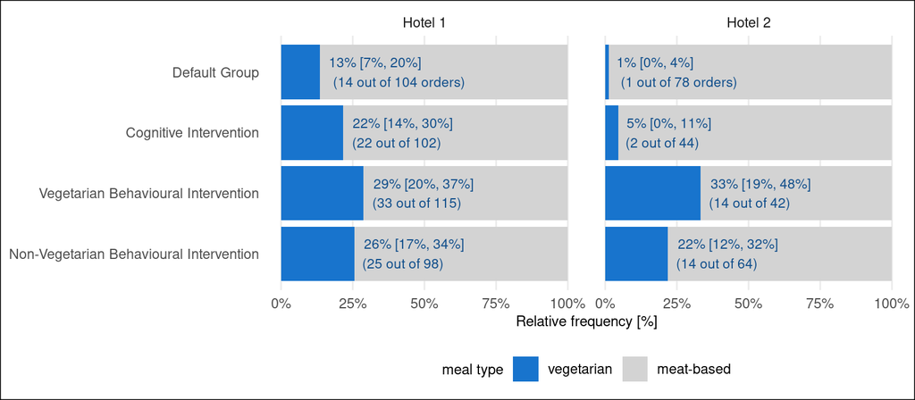

```r
plot_dat <- dat %>%
  filter(!is.na(meal_type)) %>%
  mutate(hotel        = factor(hotel, levels = c("hotel 1", "hotel 2"), labels = c("Hotel 1", "Hotel 2")),
         meal_type    = factor(meal_type, levels = c("V", "M"), labels = c("vegetarian", "meat-based")),
         intervention = factor(intervention, levels = rev(levels(intervention))))

plotLabels_dat <- plot_dat %>%
  group_by(hotel, intervention) %>%
  summarize(n_veg             = sum(meal_type == "vegetarian"),
            n_total           = n(),
            veg_share         = n_veg / n_total,
            veg_share_se      = sqrt((veg_share * (1 - veg_share) / n_total)),
            veg_share_CIlower = veg_share - qnorm(.975) * veg_share_se,
            veg_share_CIupper = veg_share + qnorm(.975) * veg_share_se) %>%
  mutate(veg_share_CIlower = case_when(veg_share_CIlower < 0 ~ 0,
                                       TRUE                  ~ veg_share_CIlower),
         veg_share_label = case_when(intervention == "Default Group" ~ paste0(scales::percent(veg_share, accuracy = 1), " [",
                                                                              scales::percent(veg_share_CIlower, accuracy = 1), ", ",
                                                                              scales::percent(veg_share_CIupper, accuracy = 1), "]\n(",
                                                                              n_veg, " out of ", n_total, " orders)"),
                                     TRUE                            ~ paste0(scales::percent(veg_share, accuracy = 1), " [",
                                                                              scales::percent(veg_share_CIlower, accuracy = 1), ", ",
                                                                              scales::percent(veg_share_CIupper, accuracy = 1), "]\n(",
                                                                              n_veg, " out of ", n_total, ")")))

plot_dat %>%
  ggplot(aes(y = intervention)) +
  geom_bar(aes(fill = meal_type), position = position_fill(reverse = TRUE)) +
  geom_text(data = plotLabels_dat, aes(label = veg_share_label, x = veg_share),
            hjust = -0.1, col = "dodgerblue4", size = 3) +
  scale_fill_manual("meal type", values = c("dodgerblue3", "lightgray")) +
  scale_x_continuous("Relative frequency [%]", labels = scales::label_percent()) +
  facet_wrap(~ hotel) +
  theme(axis.title.y       = element_blank(),
        axis.title.x       = element_text(size = 9),
        plot.background    = element_rect(fill = "white"),
        panel.grid.major.y = element_blank(),
        panel.grid.minor.x = element_blank(),
        legend.position    = "bottom",
        legend.title       = element_text(size = 9))
```

```r
# ggsave("results/Figure3_description.png", width = 8, height = 3.5)
```

# Model estimation

We estimate two models to answer the hypotheses:

1. One general model jointly comparing the two behavioural interventions with the cognitive intervention
2. One detailed model comparing all three interventions with each other

## Main model 1: Behavioural interventions vs. Cognitive intervention

Estimation of a logistic regression model on individual level

- response variable: binary indicator ‘vegetarian vs. non-vegetarian choice’
- main independent variable: intervention (with the two categories ‘Cognitive Intervention’ and ‘Behavioural Intervention’; excluding the control group, also as of the low numbers of the control group in hotel 2)
- main control variable: hotel indicator (binary), as an interaction with all other variables

```r
### data preparation
# drop the control group
dat_noControl <- dat %>%
  filter(intervention != "Default Group") %>%
  mutate(intervention = droplevels(intervention))
# create a new intervention variable joining the two behavioural interventions
dat_noControl <- dat_noControl %>%
  mutate(intervention_grouped = factor(intervention,
                                       levels = c("Cognitive Intervention",
                                                  "Vegetarian Behavioural Intervention",
                                                  "Non-Vegetarian Behavioural Intervention"),
                                       labels = c("Cognitive Intervention",
                                                  "Behavioural Interventions",
                                                  "Behavioural Interventions")))

### model estimation
model1 <- glm(meal_type ~ hotel*intervention_grouped,
              family = binomial(link = "logit"), data = dat_noControl)

### summary table for the model
# base: reestimate the model with 'hotel 2' as reference category, to easily
#       retrieve the 'hotel 2'-specific intervention estimates and confidence intervals
model1_ref2 <- dat_noControl %>%
  mutate(hotel = relevel(hotel, ref = "hotel 2")) %>%
  glm(meal_type ~ hotel*intervention_grouped,
      family = binomial(link = "logit"), data = .)
# retrieve the two coefficient tables
coef1_tab1 <- summary(model1)$coefficients %>%
  as.data.frame() %>%
  mutate(parameter = row.names(.)) %>%
  filter(!grepl("hotel 2:", parameter)) %>%
  mutate(parameter = gsub("intervention_grouped", "hotel 1 intervention", parameter))
row.names(coef1_tab1) <- NULL
coef1_tab2 <- summary(model1_ref2)$coefficients %>%
  as.data.frame() %>%
  mutate(parameter = row.names(.)) %>%
  filter(!grepl("hotel 1:", parameter),
         grepl("intervention", parameter)) %>%
  mutate(parameter = gsub("intervention_grouped", "hotel 2 intervention", parameter))
row.names(coef1_tab2) <- NULL
# merge the two tables
coef1_tab <- bind_rows(coef1_tab1, coef1_tab2)
# final preparations
coef1_tab <- coef1_tab %>%
  rename(coef   = Estimate,
         se     = "Std. Error",
         pvalue = "Pr(>|z|)") %>%
  mutate(coef_exp     = exp(coef),
         se_exp       = exp(se),
         CI_lower     = coef - qnorm(0.975) * se,
         CI_upper     = coef + qnorm(0.975) * se,
         CI_lower_exp = exp(CI_lower),
         CI_upper_exp = exp(CI_upper)) %>%
  select(parameter, coef, se, coef_exp, se_exp, CI_lower_exp, CI_upper_exp, pvalue) %>%
  mutate(across(c(coef, se, coef_exp, se_exp, CI_lower_exp, CI_upper_exp), function(x) { round(x, 2) }),
         pvalue    = round(pvalue, 4),
         pvalue    = case_when(parameter == "(Intercept)" ~ "-",
                               pvalue    <  0.0001        ~ "<0.0001",
                               TRUE                       ~ as.character(pvalue)),
         parameter = case_when(parameter == "(Intercept)"         ~ "intercept",
                               parameter == "hotelhotel 2"        ~ "hotel 2",
                               grepl("intervention", parameter)   ~ gsub("intervention", "intervention ", parameter),
                               TRUE                               ~ parameter))

coef1_tab %>% kable() %>% kable_styling()
```

[output not shown]

```r
# write.csv(coef1_tab, file = "results/model1_results.csv", row.names = FALSE)
```

### Effect plot

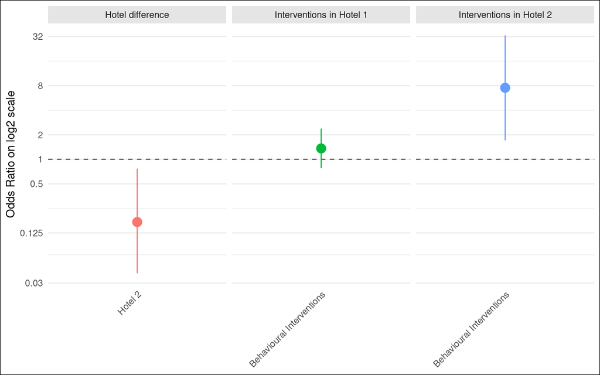

```r
# create a 'param_group' variable to categorize the effects in the plot
coef1_tab_plot <- coef1_tab %>%
  filter(parameter != "intercept") %>%
  mutate(param_group = case_when(grepl("hotel 1 int", parameter) ~ "Interventions in Hotel 1",
                                 grepl("hotel 2 int", parameter) ~ "Interventions in Hotel 2",
                                 TRUE                            ~ "Hotel difference"),
         param_group = factor(param_group),
         parameter   = gsub("hotel 1 intervention ", "", parameter),
         parameter   = gsub("hotel 2 intervention ", "", parameter),
         parameter   = case_when(parameter == "hotel 2" ~ "Hotel 2",
                                 TRUE                   ~ parameter),
         parameter   = factor(parameter, levels = c("Hotel 2", "Cognitive Intervention",
                                                    "Behavioural Interventions")))
# plot
ggplot(coef1_tab_plot, aes(x = parameter)) +
  geom_hline(yintercept = 1, col = "gray30", lty = 2) +
  geom_pointrange(aes(xmin = parameter, xmax = parameter, y = coef_exp,
                      ymin = CI_lower_exp, ymax = CI_upper_exp, col = param_group),
                  size = .8) +
  facet_grid(~ param_group, scales = "free_x") +
  scale_y_continuous("Odds Ratio on log2 scale", trans = "log2",
                     breaks       = c(0.030375, 0.125, 0.5, 1, 2, 8, 32, 128),
                     minor_breaks = c(0.0675, 0.25, 4, 16, 64, 256),
                     labels       = c("0.03", "0.125", "0.5", "1", "2", "8", "32", "128")) +
  theme(legend.position    = "none",
        plot.background    = element_rect(fill = "white"),
        strip.background   = element_rect(fill = "gray90", color = "transparent"),
        panel.grid.major.x = element_blank(),
        axis.title.x       = element_blank(),
        axis.text.x        = element_text(angle = 45, hjust = 1))
```

```r
# ggsave("results/model1_effectPlot.png", width = 8, height = 5)
```

### Goodness of fit

```r
dispersion_parameter1 <- model1$deviance / model1$df.residual
```

Dispersion parameter: 1.07

## Main model 2: Comparison of all three interventions

Estimation of a logistic regression model, identical to model 1, with the only difference that the two behavioural intervention groups are analysed separately.

```r
### model estimation
model2 <- glm(meal_type ~ hotel*intervention,
              family = binomial(link = "logit"), data = dat_noControl)

### summary table for the model
# base: reestimate the model with 'hotel 2' as reference category, to easily
#       retrieve the 'hotel 2'-specific intervention estimates and confidence intervals
model2_ref2 <- dat_noControl %>%
  mutate(hotel = relevel(hotel, ref = "hotel 2")) %>%
  glm(meal_type ~ hotel*intervention,
      family = binomial(link = "logit"), data = .)
# retrieve the two coefficient tables
coef2_tab1 <- summary(model2)$coefficients %>%
  as.data.frame() %>%
  mutate(parameter = row.names(.)) %>%
  filter(!grepl("hotel 2:", parameter)) %>%
  mutate(parameter = gsub("intervention", "hotel 1 intervention", parameter))
row.names(coef2_tab1) <- NULL
coef2_tab2 <- summary(model2_ref2)$coefficients %>%
  as.data.frame() %>%
  mutate(parameter = row.names(.)) %>%
  filter(!grepl("hotel 1:", parameter),
         grepl("intervention", parameter)) %>%
  mutate(parameter = gsub("intervention", "hotel 2 intervention", parameter))
row.names(coef2_tab2) <- NULL
# merge the two tables
coef2_tab <- bind_rows(coef2_tab1, coef2_tab2)
# final preparations
coef2_tab <- coef2_tab %>%
  rename(coef   = Estimate,
         se     = "Std. Error",
         pvalue = "Pr(>|z|)") %>%
  mutate(coef_exp     = exp(coef),
         se_exp       = exp(se),
         CI_lower     = coef - qnorm(0.975) * se,
         CI_upper     = coef + qnorm(0.975) * se,
         CI_lower_exp = exp(CI_lower),
         CI_upper_exp = exp(CI_upper)) %>%
  select(parameter, coef, se, coef_exp, se_exp, CI_lower_exp, CI_upper_exp, pvalue) %>%
  mutate(across(c(coef, se, coef_exp, se_exp, CI_lower_exp, CI_upper_exp), function(x) { round(x, 2) }),
         pvalue    = round(pvalue, 4),
         pvalue    = case_when(parameter == "(Intercept)" ~ "-",
                               pvalue    <  0.0001        ~ "<0.0001",
                               TRUE                       ~ as.character(pvalue)),
         parameter = case_when(parameter == "(Intercept)"         ~ "intercept",
                               parameter == "hotelhotel 2"        ~ "hotel 2",
                               grepl("intervention", parameter)   ~ gsub("intervention", "intervention ", parameter),
                               TRUE                               ~ parameter))

coef2_tab %>% kable() %>% kable_styling()
```

| parameter | coef | se | coef_exp | se_exp | CI_lower_exp | CI_upper_exp | pvalue |
| --- | --- | --- | --- | --- | --- | --- | --- |
| intercept | -1.29 | 0.24 | 0.28 | 1.27 | 0.17 | 0.44 | - |
| hotel 2 | -1.75 | 0.76 | 0.17 | 2.14 | 0.04 | 0.77 | 0.0215 |
| hotel 1 intervention Vegetarian Behavioural Intervention | 0.38 | 0.32 | 1.46 | 1.37 | 0.79 | 2.72 | 0.2296 |
| hotel 1 intervention Non-Vegetarian Behavioural Intervention | 0.22 | 0.33 | 1.25 | 1.40 | 0.65 | 2.40 | 0.5114 |
| hotel 2 intervention Vegetarian Behavioural Intervention | 2.35 | 0.79 | 10.50 | 2.21 | 2.21 | 49.80 | 0.0031 |
| hotel 2 intervention Non-Vegetarian Behavioural Intervention | 1.77 | 0.78 | 5.88 | 2.19 | 1.26 | 27.35 | 0.0239 |

```r
# write.csv(coef2_tab, file = "results/model2_results.csv", row.names = FALSE)
```

### Effect plot

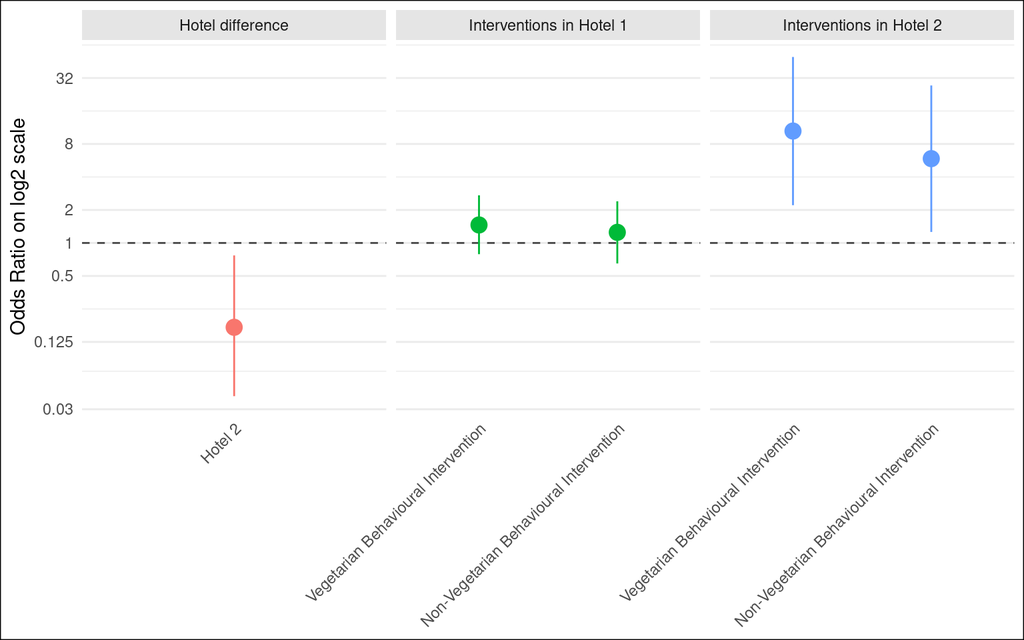

```r
# create a 'param_group' variable to categorize the effects in the plot
coef2_tab_plot <- coef2_tab %>%
  filter(parameter != "intercept") %>%
  mutate(param_group = case_when(grepl("hotel 1 int", parameter) ~ "Interventions in Hotel 1",
                                 grepl("hotel 2 int", parameter) ~ "Interventions in Hotel 2",
                                 TRUE                            ~ "Hotel difference"),
         param_group = factor(param_group),
         parameter   = gsub("hotel 1 intervention ", "", parameter),
         parameter   = gsub("hotel 2 intervention ", "", parameter),
         parameter   = case_when(parameter == "hotel 2" ~ "Hotel 2",
                                 TRUE                   ~ parameter),
         parameter   = factor(parameter, levels = c("Hotel 2", "Cognitive Intervention",
                                                    "Vegetarian Behavioural Intervention",
                                                    "Non-Vegetarian Behavioural Intervention")))
# plot
ggplot(coef2_tab_plot, aes(x = parameter)) +
  geom_hline(yintercept = 1, col = "gray30", lty = 2) +
  geom_pointrange(aes(xmin = parameter, xmax = parameter, y = coef_exp,
                      ymin = CI_lower_exp, ymax = CI_upper_exp, col = param_group),
                  size = .8) +
  facet_grid(~ param_group, scales = "free_x") +
  scale_y_continuous("Odds Ratio on log2 scale", trans = "log2",
                     breaks       = c(0.030375, 0.125, 0.5, 1, 2, 8, 32, 128),
                     minor_breaks = c(0.0675, 0.25, 4, 16, 64, 256),
                     labels       = c("0.03", "0.125", "0.5", "1", "2", "8", "32", "128")) +
  theme(legend.position    = "none",
        plot.background    = element_rect(fill = "white"),
        strip.background   = element_rect(fill = "gray90", color = "transparent"),
        panel.grid.major.x = element_blank(),
        axis.title.x       = element_blank(),
        axis.text.x        = element_text(angle = 45, hjust = 1))
```

```r
# ggsave("results/Figure4_model2_effectPlot.png", width = 8, height = 5)
```

### Goodness of fit

```r
dispersion_parameter2 <- model2$deviance / model2$df.residual
```

Dispersion parameter: 1.07

# Answering the hypotheses

## H1: Behavioural > cognitive

**Hypothesis**  
A behavioural intervention is more effective than a cognitive intervention in increasing vegetarian orders in a hotel restaurant setting.

```r
coef1_tab %>%
  filter(grepl("Intervention", parameter)) %>%
  select(-coef, -se, -se_exp) %>%
  kable() %>%
  kable_styling()
```

| parameter | coef_exp | CI_lower_exp | CI_upper_exp | pvalue |
| --- | --- | --- | --- | --- |
| hotel 1 intervention Behavioural Interventions | 1.36 | 0.78 | 2.38 | 0.2811 |
| hotel 2 intervention Behavioural Interventions | 7.54 | 1.71 | 33.20 | 0.0076 |

**Result**  
Only in hotel 2, the behavioural intervention led to a significant increase in vegetarian orders, compared to the cognitive intervention.  
In hotel 1, the chance for a guest to order a vegetarian meal was overall increased by 36% (p = 0.2811) if the guest underwent a behavioural instead of the cognitive intervention.  
In hotel 2, this chance was increased by 654% (p = 0.0076).

## H2a: Veg. behavioural > cognitive

**Hypothesis**  
The Vegetarian Intervention is more effective than the Cognitive Intervention in increasing vegetarian orders in a hotel restaurant setting.

```r
coef2_tab %>%
  filter(grepl(" Vegetarian", parameter)) %>%
  select(-coef, -se, -se_exp) %>%
  kable() %>%
  kable_styling()
```

| parameter | coef_exp | CI_lower_exp | CI_upper_exp | pvalue |
| --- | --- | --- | --- | --- |
| hotel 1 intervention Vegetarian Behavioural Intervention | 1.46 | 0.79 | 2.72 | 0.2296 |
| hotel 2 intervention Vegetarian Behavioural Intervention | 10.50 | 2.21 | 49.80 | 0.0031 |

**Result**  
Only in hotel 2, the vegetarian behavioural intervention led to a significant increase in vegetarian orders, compared to the cognitive intervention.  
In hotel 1, the chance for a guest to order a vegetarian meal was increased by 46% (p = 0.2296) if the guest underwent the vegetarian behavioural intervention instead of the cognitive intervention.  
In hotel 2, this chance was increased by 950% (p = 0.0031).

## H2b: Non-Veg. behavioural < cognitive

**Hypothesis**  
The Non-Vegetarian Intervention is less effective than the Cognitive Intervention in increasing vegetarian orders in a hotel restaurant setting.

```r
coef2_tab %>%
  filter(grepl("Non-Vegetarian", parameter)) %>%
  select(-coef, -se, -se_exp) %>%
  kable() %>%
  kable_styling()
```

| parameter | coef_exp | CI_lower_exp | CI_upper_exp | pvalue |
| --- | --- | --- | --- | --- |
| hotel 1 intervention Non-Vegetarian Behavioural Intervention | 1.25 | 0.65 | 2.40 | 0.5114 |
| hotel 2 intervention Non-Vegetarian Behavioural Intervention | 5.88 | 1.26 | 27.35 | 0.0239 |

## Additionally: Hotel difference?

**Additional question**  
Is there a significant difference between the two hotels regarding the assocation structure between the interventions and the response?

**Approach**  
Estimate model 2 (the one comparing all three intervention groups) once without the hotel effect and perform a likelihood ratio test.

```r
# model estimation
model2_noHotel <- glm(meal_type ~ intervention,
                      family = binomial(link = "logit"), data = dat_noControl)

model2_anova <- anova(model2, model2_noHotel, test = "LRT")
```

**Result**  
Yes, there is a significant difference between the association structures in the two hotels (p = 0.0377).

# CO2 savings in hotel 2

Based on our sample (for all covered days we observed all ordered dinner meals) we estimate the **yearly dinner CO2 emissions** of hotel 2, once based on the default group and once based on the vegetarian behavioural intervention group.

Assumptions:

- hotel 2 is a conference center, only opened on weekdays (dinner is served there Monday to Friday)
- since only dinner is freely chosen by the guests we focus solely on the dinner CO2 emissions
- we assume that hotel 2 is opened the whole 52 weeks in a year
- a non-vegetarian dinner meal in hotel 2 has an average CO2 footprint of 2.9kg
- a vegetarian dinner meal in hotel 2 has an average CO2 footprint of 1.7kg

```r
# base information
dat_hotel2     <- dat %>% filter(hotel == "hotel 2")
n_days         <- dat_hotel2$date %>% unique() %>% length()
n_mealsPerDay  <- nrow(dat_hotel2) / n_days
n_mealsPerYear <- n_mealsPerDay * 5 * 52

# meal orders
mealOrders_default <- dat_hotel2 %>%
  filter(intervention == "Default Group") %>%
  pull(meal_type) %>%
  table() %>%
  prop.table()
mealOrders_intervention <- dat_hotel2 %>%
  filter(intervention == "Vegetarian Behavioural Intervention") %>%
  pull(meal_type) %>%
  table() %>%
  prop.table()

# CO2 emissions
CO2_kg_default <- unname(n_mealsPerYear * mealOrders_default["M"] * 2.9 +
                           n_mealsPerYear * mealOrders_default["V"] * 1.7)
CO2_kg_intervention <- unname(n_mealsPerYear * mealOrders_intervention["M"] * 2.9 +
                                n_mealsPerYear * mealOrders_intervention["V"] * 1.7)
```

Based on our 12 observed days in hotel 2 and its on average 19 dinner meals ordered per day we estimate that per year (5 days per one of the 52 weeks) 4940 dinner meals are ordered in hotel 2.

Assuming the application of no intervention (i.e. based on the **default group**) we would assume that on average 4876.67 (98.7%) dinner meals per year are non-vegetarian and 63.33 (1.3%) are vegetarian, resulting in a total CO2 footprimt of **14.2 tons**.

Assuming the application of the **vegetarian behavioural intervention** we would assume that on average 3293.33 (66.7%) dinner meals per year are non-vegetarian and 1646.67 (33.3%) are vegetarian, resulting in a total CO2 footprimt of **12.3 tons**.

Accordingly the vegetarian behavioural intervention could **save 13% of dinner CO2 emissions**.